# BMIN503 Final Project: Disparities in managing migraine pain in the pediatric ER

Sansanee Craig

December 11, 2018

## Overview

Racial disparities in pain management have been documented in the adult and pediatric population. Most studies have focused on pathologies with definitive diagnostic testing, such as appendicitis, long-bone fractures, and sickle cell disease. Few studies have assessed variability of pain management in pediatric migraine. The purpose of this project is to utilize secondary analysis of EHR data to determine if race/ethnicity-based differences exist in the management of pediatric migraine pain in the emergency room at the Children’s Hospital of Philadelphia (CHOP).

## Introduction

Pain management cross-sects most fields of medical practice. In the case of migraine pain, a patien’s care team may comprise a primary care physician and a neurologist, with ER and hospitalist providers added during refractory migraine episodes. Alleviating pain efficiently, safely, and equally for all patients is the ultimate goal during an emergency room visit. In the few pediatric studies to date, however, some sociodemographic disparities have been shown to exist in pediatric headache care across the United States.  
In beginning to study this issue, thoughtful data queries in conjunction with data analysts is vital as the choices behind codifying race and ethnicity alone could significantly alter study results. Workflow analysis during direct observations in the ER provides insight into missing field factors, such as non-mandatory data entry in assigning a pain scale/score or completing demographic fields. Nurses’ feedback sheds light on why pain reassessment alerts were being ignored or pain scales not being assigned during registration. Discussions with ER physicians and the ER director provides background information on previous disparities study results and QI projects, identifying most relevant outcome to study, and factors in choosing which statistical result to report. Meeting with a pediatric neurologist, the director of the headache clinic, results in an additional view of focusing QI efforts on giving primary care providers better tools to care for migraine pain in order to decrease unnecessary neurology referrals or ER visits. In short, data scientists and quality improvement (QI) teams can contribute to understanding the best methods to study where these disparities lie and how to rapidly conduct improvement projects to decrease known disparities. Clinical informaticists help to facilitate change management by navigating the socio-technical factors in hospital and clinic organizations. Thus, this is a multidisciplinary project with stakeholders spanning the field biomedical and health informatics.

## Methods & Results

The data used in this project were imported as a CSV file from Qlikview, a software that displays results from SQL queries written by CHOP data analysts. This SQL query specifically pulls data from the CHOP EMR (Epic) on patients ages 5 -18 who were diagnosed with migraine as specificed by two ICD-10 codes. Results exported as .xlsx file were de-identified before saving as a .csv file for import to R. All data available in Qlikview were imported without filtering. The first observation was noted to be missing MRN and 20 other variables, so was assumed error and deleted before import.

### Data loading and cleaning

#### Load data set, assign NA’s, transform variable classes

```r
data_all<- read.csv("https://raw.githubusercontent.com/scraig10/BMIN503_Final_Project/master/data_all_11_28_2018.csv", header=TRUE)
str(data_all) # 3709 observations of 33 variables
```

```
## 'data.frame':    3709 obs. of  33 variables:
##  $ X                                : int  1 2 3 4 5 6 7 8 9 10 ...
##  $ ED.Arrive                        : Factor w/ 3709 levels "1/1/2016 12:23",..: 998 997 993 992 985 984 983 968 967 966 ...
##  $ ED.LOS..min.                     : Factor w/ 638 levels "-","1,018","1,022",..: 163 1 195 193 477 49 178 121 88 141 ...
##  $ Pathway                          : Factor w/ 2 levels "No","Yes": 2 2 2 2 2 2 2 2 2 2 ...
##  $ Sex                              : Factor w/ 2 levels "F","M": 2 1 1 2 1 1 1 1 1 2 ...
##  $ Race.Ethnicity                   : Factor w/ 4 levels "HISPANIC OR LATINO",..: 4 1 3 2 2 4 1 3 2 3 ...
##  $ Payer.Type                       : Factor w/ 3 levels "-","COMMERCIAL",..: 2 3 3 3 3 2 2 2 3 2 ...
##  $ Primary.Language                 : Factor w/ 2 levels "ENGLISH","NON-ENGLISH": 1 1 1 1 1 1 1 1 1 1 ...
##  $ Acuity                           : Factor w/ 5 levels "1 Critical","2 Acute",..: 3 3 3 3 3 4 3 3 3 3 ...
##  $ CCC                              : Factor w/ 2 levels "No","Yes": 1 1 2 2 2 2 1 2 1 2 ...
##  $ HCG                              : Factor w/ 2 levels "No","Yes": 1 1 2 1 2 1 2 2 2 1 ...
##  $ HCG.Result                       : Factor w/ 1830 levels "-","1/1/2015 0:31",..: 1 1 493 1 1 1 492 484 483 1 ...
##  $ Arrive.to.Room                   : int  11 32 12 3 2 4 3 5 10 4 ...
##  $ Room.to.MD.Eval                  : int  30 31 12 23 1 10 7 3 2 4 ...
```

[output cut: 19 more lines]

```r
summary(data_all) #First glance, it seems there are no missing variables.
```

```
##        X                  ED.Arrive     ED.LOS..min.  Pathway    Sex
##  Min.   :   1   1/1/2016 12:23 :   1   213    :  22   No : 645   F:2615
##  1st Qu.: 928   1/1/2017 11:18 :   1   255    :  22   Yes:3064   M:1094
##  Median :1855   1/10/2014 12:17:   1   199    :  20
##  Mean   :1855   1/10/2016 18:34:   1   261    :  20
##  3rd Qu.:2782   1/10/2016 19:26:   1   216    :  19
##  Max.   :3709   1/10/2017 14:10:   1   204    :  18
##                 (Other)        :3703   (Other):3588
##             Race.Ethnicity              Payer.Type      Primary.Language
##  HISPANIC OR LATINO: 264   -                 : 112   ENGLISH    :3641
##  NON-HISPANIC BLACK:1514   COMMERCIAL        :2089   NON-ENGLISH:  68
##  NON-HISPANIC WHITE:1750   MEDICAL ASSISTANCE:1508
##  OTHER             : 181
##
##
##
##           Acuity      CCC        HCG                  HCG.Result
##  1 Critical  :   7   No :2095   No :1664   -               :1873
##  2 Acute     : 623   Yes:1614   Yes:2045   1/31/2015 19:01 :   2
##  3 Urgent    :2753                         11/7/2014 11:55 :   2
##  4 Urgent    : 312                         12/11/2017 21:18:   2
##  5 Non-Urgent:  14                         2/25/2014 20:26 :   2
##                                            3/24/2015 10:20 :   2
##                                            (Other)         :1826
##  Arrive.to.Room   Room.to.MD.Eval  MD.Eval.to.First.Med.Order
##  Min.   :-56.00   Min.   :-15.00   -      : 451
##  1st Qu.:  4.00   1st Qu.:  3.00   19     :  67
##  Median :  9.00   Median :  9.00   20     :  63
##  Mean   : 24.84   Mean   : 19.41   23     :  61
##  3rd Qu.: 29.00   3rd Qu.: 26.00   29     :  59
##  Max.   :405.00   Max.   :293.00   26     :  58
##                                    (Other):2950
##  X1st.Med.Ordered.to.Started X1st.Med.Started.to.Given
##  -      : 451                0      : 563
##  21     :  90                -      : 451
##  27     :  89                1      :  75
##  26     :  88                20     :  71
##  24     :  87                21     :  63
##  23     :  83                18     :  61
##  (Other):2821                (Other):2425
```

[output cut: 33 more lines]

```
##  -      :2973          NONE                         :2406   No :3600
##  20     :  18          VALPROATE                    : 463   Yes: 109
##  60     :  16          VALPROATE, METHYLPREDNISOLONE: 273
##  31     :  15          -                            : 194
##  32     :  14          METHYLPREDNISOLONE           : 172
##  55     :  14          ALL                          :  75
##  (Other): 659          (Other)                      : 126
##  X7d.Revisit        Dispo      Team.Assessment.
##  No :3524    Admitted  : 597   -:   4
##  Yes: 185    Discharged:3112   0:3414
##                                1: 291
##
##
##
##
```

```r
pct_miss_var(data_all) #No missing data values , using NaNiar package
```

```
## [1] 0
```

```r
table_miss_var <- miss_var_table(data_all) # create table of all missing data in all variables
print(table_miss_var)  #Zero data missing in all 33 variables that comprise 100% of the data set
```

```
## # A tibble: 1 x 3
##   n_miss_in_var n_vars pct_vars
##           <int>  <int>    <dbl>
## 1             0     33      100
```

```r
sum(is.na(data_all)) #Similarly, there are zero NAs
```

```
## [1] 0
```

```r
#However, realized that spaces and dashes were not being coded as NA so assigned NAs to blanks, spaces, and dashes
data_all_na <- read.csv("https://raw.githubusercontent.com/scraig10/BMIN503_Final_Project/master/data_all_11_28_2018.csv", header=T, na.strings=c(""," ","NA", "-"))
summary(data_all_na) #Now, NA's appear in the summary tables
```

```
##        X                  ED.Arrive     ED.LOS..min.  Pathway    Sex
##  Min.   :   1   1/1/2016 12:23 :   1   213    :  22   No : 645   F:2615
##  1st Qu.: 928   1/1/2017 11:18 :   1   255    :  22   Yes:3064   M:1094
##  Median :1855   1/10/2014 12:17:   1   199    :  20
##  Mean   :1855   1/10/2016 18:34:   1   261    :  20
##  3rd Qu.:2782   1/10/2016 19:26:   1   216    :  19
##  Max.   :3709   1/10/2017 14:10:   1   (Other):3605
##                 (Other)        :3703   NA's   :   1
##             Race.Ethnicity              Payer.Type      Primary.Language
##  HISPANIC OR LATINO: 264   COMMERCIAL        :2089   ENGLISH    :3641
##  NON-HISPANIC BLACK:1514   MEDICAL ASSISTANCE:1508   NON-ENGLISH:  68
##  NON-HISPANIC WHITE:1750   NA's              : 112
##  OTHER             : 181
##
##
##
##           Acuity      CCC        HCG                  HCG.Result
##  1 Critical  :   7   No :2095   No :1664   1/31/2015 19:01 :   2
##  2 Acute     : 623   Yes:1614   Yes:2045   11/7/2014 11:55 :   2
##  3 Urgent    :2753                         12/11/2017 21:18:   2
##  4 Urgent    : 312                         2/25/2014 20:26 :   2
##  5 Non-Urgent:  14                         3/24/2015 10:20 :   2
##                                            (Other)         :1826
##                                            NA's            :1873
##  Arrive.to.Room   Room.to.MD.Eval  MD.Eval.to.First.Med.Order
##  Min.   :-56.00   Min.   :-15.00   Min.   :-128.00
##  1st Qu.:  4.00   1st Qu.:  3.00   1st Qu.:  21.00
##  Median :  9.00   Median :  9.00   Median :  37.00
##  Mean   : 24.84   Mean   : 19.41   Mean   :  48.52
##  3rd Qu.: 29.00   3rd Qu.: 26.00   3rd Qu.:  61.00
##  Max.   :405.00   Max.   :293.00   Max.   : 536.00
##                                    NA's   :451
##  X1st.Med.Ordered.to.Started X1st.Med.Started.to.Given
##  21     :  90                0      : 563
##  27     :  89                1      :  75
##  26     :  88                20     :  71
##  24     :  87                21     :  63
##  23     :  83                18     :  61
##  (Other):2821                (Other):2425
##  NA's   : 451                NA's   : 451
```

[output cut: 33 more lines]

```
##  Min.   : 20.00        NONE                         :2406   No :3600
##  1st Qu.: 42.00        VALPROATE                    : 463   Yes: 109
##  Median : 63.00        VALPROATE, METHYLPREDNISOLONE: 273
##  Mean   : 77.21        METHYLPREDNISOLONE           : 172
##  3rd Qu.: 92.25        ALL                          :  75
##  Max.   :441.00        (Other)                      : 126
##  NA's   :2973          NA's                         : 194
##  X7d.Revisit        Dispo      Team.Assessment.
##  No :3524    Admitted  : 597   Min.   :0.00000
##  Yes: 185    Discharged:3112   1st Qu.:0.00000
##                                Median :0.00000
##                                Mean   :0.07854
##                                3rd Qu.:0.00000
##                                Max.   :1.00000
##                                NA's   :4
```

```r
# Change team assessment from integer to factor with assigned labels based on chart and Qlikview review for clearer summary statistics
data_all_na <- mutate(data_all_na, Team.Assessment. = factor(Team.Assessment. , levels=c(0,1), labels = c("No", "Yes")))
```

My hypothesis is that race and ethnicity , particularly NH black race, is significantly correlated to longer time from arrival to receiving first line medication. Secondary variables include disposition (admitted vs discharge), whether a team assessment occurred, and whether the pathway was utilized.

Acuity could be considered a subjective assessment that might be influenced by implicit bias. The one pediatric headache study which was in the outpt clinic, did show that AA children received the diagnosis of headache less frequently than white children.

However, because acuity is an objective starting point for the orders and evaluations to be done, I added it to the predictor variables in my linear regression. Iie How does the primary outcome change given the same acuity level across different demographic groups?)

Other variables were not included in this project to date.

```r
#Create data frame of select variables of interest
data_select <- data_all_na %>%
  select(Pathway,Sex, Race.Ethnicity, Payer.Type, Primary.Language, Acuity,Arrive.to.1st.Med.Given, Dispo, Team.Assessment.)
```

### Data Quality: General inspection of mins/max

Arrive to room should never have a negative number while MD eval to first med order could have a negative number (provider hears of pt being referred from clinic or looks at pt’s chart and see’s is a chronic pt, already puts in orders they know pt will need) If I was using these metrics I would have to further look into these and potentially eliminate or manually recalculate the negative observations, as it is I just used arrive to first med Given which does not on first inspection have this obvious error.

```r
describe(data_all_na) #summary of data set
```

```
##                                   vars    n    mean      sd median trimmed
## X                                    1 3709 1855.00 1070.84 1855.0 1855.00
## ED.Arrive*                           2 3709 1855.00 1070.84 1855.0 1855.00
## ED.LOS..min.*                        3 3708  238.59  137.59  209.0  225.65
## Pathway*                             4 3709    1.83    0.38    2.0    1.91
## Sex*                                 5 3709    1.29    0.46    1.0    1.24
## Race.Ethnicity*                      6 3709    2.50    0.70    3.0    2.53
## Payer.Type*                          7 3597    1.42    0.49    1.0    1.40
## Primary.Language*                    8 3709    1.02    0.13    1.0    1.00
## Acuity*                              9 3709    2.92    0.52    3.0    2.91
## CCC*                                10 3709    1.44    0.50    1.0    1.42
## HCG*                                11 3709    1.55    0.50    2.0    1.56
## HCG.Result*                         12 1836  915.07  528.21  914.5  915.04
## Arrive.to.Room                      13 3709   24.84   37.08    9.0   16.33
## Room.to.MD.Eval                     14 3709   19.41   27.20    9.0   13.71
## MD.Eval.to.First.Med.Order          15 3258   48.52   49.16   37.0   41.03
## X1st.Med.Ordered.to.Started*        16 3258   93.15   25.21   92.0   92.75
## X1st.Med.Started.to.Given*          17 3258  121.28   81.88  131.0  121.61
## Bolus.Start*                        18 2863 1430.60  826.06 1431.0 1430.54
## Toradol.Given*                      19 2556 1277.43  737.20 1277.5 1277.41
## Reglan.Start*                       20 2938 1463.77  845.25 1462.5 1463.51
## Reglan.Given*                       21 2938 1464.90  846.68 1464.5 1464.60
## Reglan.Infusion.Time*               22 2938   28.41   29.50   26.0   23.73
## Reglan.Route*                       23 2938    1.29    0.71    1.0    1.12
## Arrive.to.1st.Med.Given             24 3258  163.22   85.47  144.0  152.07
## X1st.Med.Reassessment               25 2431   68.78   47.18   56.0   60.96
## X1st.Med.Given.to.2nd.Med.Ordered   26 1102   48.36   83.63   53.0   52.41
## Initial.2nd.Med.Given*              27 1109    2.61    0.60    3.0    2.72
## X2nd.Med.Reassessment               28  736   77.21   52.59   63.0   68.89
## X2nd.Meds.Given*                    29 3515    5.18    1.23    5.0    5.16
## X72hr.Revisit*                      30 3709    1.03    0.17    1.0    1.00
## X7d.Revisit*                        31 3709    1.05    0.22    1.0    1.00
## Dispo*                              32 3709    1.84    0.37    2.0    1.92
## Team.Assessment.*                   33 3705    1.08    0.27    1.0    1.00
##                                       mad  min  max range  skew kurtosis
## X                                 1374.37    1 3709  3708  0.00    -1.20
## ED.Arrive*                        1374.37    1 3709  3708  0.00    -1.20
## ED.LOS..min.*                      130.47    1  637   636  0.78     0.01
## Pathway*                             0.00    1    2     1 -1.72     0.96
## Sex*                                 0.00    1    2     1  0.90    -1.19
```

[output cut: 47 more lines]

```
## Toradol.Given*                    14.58
## Reglan.Start*                     15.59
## Reglan.Given*                     15.62
## Reglan.Infusion.Time*              0.54
## Reglan.Route*                      0.01
## Arrive.to.1st.Med.Given            1.50
## X1st.Med.Reassessment              0.96
## X1st.Med.Given.to.2nd.Med.Ordered  2.52
## Initial.2nd.Med.Given*             0.02
## X2nd.Med.Reassessment              1.94
## X2nd.Meds.Given*                   0.02
## X72hr.Revisit*                     0.00
## X7d.Revisit*                       0.00
## Dispo*                             0.01
## Team.Assessment.*                  0.00
```

However note that max times seem excessively long: 13 hours from arrival to first med given?? Using chart review, observation 3224 is the most extreme outlier, verified in chart review that this is not erroneous data. Pt truly did wait 14 hours to receive IV medications because not clear cut migraine diagnosis, although she did get a bolus earlier ~ 5 hours after arrival. So I left the outliers in.

```r
#Identify outliers (had to re-download data set as I had deleted identifiers already)
data_all_na_12_11 <- read.csv("https://raw.githubusercontent.com/scraig10/BMIN503_Final_Project/master/12_11_18.csv", header=T, na.strings=c(""," ","NA", "-"))
data_all_na_12_11 <- mutate(data_all_na_12_11, Team.Assessment. = factor(Team.Assessment. , levels=c(0,1), labels = c("No", "Yes")))

max_arr <- data_all_na_12_11[which.max(data_all_na_12_11$Arrive.to.1st.Med.Given),]
print(max_arr) #find the observation which has the max value for the select variable
```

```
##         X       ED.Arrive ED.LOS..min. Pathway Sex     Race.Ethnicity
## 3224 3224 11/3/2014 21:14          906     Yes   F NON-HISPANIC WHITE
##              Payer.Type Primary.Language   Acuity CCC HCG     HCG.Result
## 3224 MEDICAL ASSISTANCE          ENGLISH 3 Urgent  No Yes 11/4/2014 0:22
##      Arrive.to.Room Room.to.MD.Eval MD.Eval.to.First.Med.Order
## 3224             74              44                        208
##      X1st.Med.Ordered.to.Started X1st.Med.Started.to.Given    Bolus.Start
## 3224                          13                       496 11/4/2014 2:53
##        Toradol.Given    Reglan.Start    Reglan.Given Reglan.Infusion.Time
## 3224 11/4/2014 11:06 11/4/2014 11:09 11/4/2014 11:09                    0
##      Reglan.Route Arrive.to.1st.Med.Given X1st.Med.Reassessment
## 3224  Intravenous                     835                    NA
##      X1st.Med.Given.to.2nd.Med.Ordered Initial.2nd.Med.Given
## 3224                                NA                  <NA>
##      X2nd.Med.Reassessment X2nd.Meds.Given X72hr.Revisit X7d.Revisit
## 3224                    NA            NONE            No          No
##           Dispo Team.Assessment.
## 3224 Discharged               No
```

### Data Quality: Evaluate missingess

The data set contains 15% missing fields. The top three variables with missing data are all related to a second line medication being given. This is because not everyone receives a second line medication, so those cells will be empty. At one end of the spectrum, 23.3% (865) of cases had 4 values missing whereas at the other end, 9.4% (349) of cases had 0 values missing. A total of 7 cases had the max count of 17 values missing. Data visualizations suggest a gradiant of missing data amongst demographic groups. The groups with the highest pct of theses missing variables is NH Black (87.52%), Hispanic (84.47%), Other (79.56%), then NH White (73.20).

```r
pct_miss(data_all_na) # %15 total missing data
```

```
## [1] 15.13844
```

```r
table_all_missing_var <-miss_var_summary(data_all_na) # table of all missing variables with n and pct, in descending order
print(table_all_missing_var)
```

```
## # A tibble: 33 x 3
##    variable                          n_miss pct_miss
##    <chr>                              <int>    <dbl>
##  1 X2nd.Med.Reassessment               2973     80.2
##  2 X1st.Med.Given.to.2nd.Med.Ordered   2607     70.3
##  3 Initial.2nd.Med.Given               2600     70.1
##  4 HCG.Result                          1873     50.5
##  5 X1st.Med.Reassessment               1278     34.5
##  6 Toradol.Given                       1153     31.1
##  7 Bolus.Start                          846     22.8
##  8 Reglan.Start                         771     20.8
##  9 Reglan.Given                         771     20.8
## 10 Reglan.Infusion.Time                 771     20.8
## # ... with 23 more rows
```

```r
table_all_missing_case <-miss_case_table(data_all_na) #table of all missing values by case.
print(table_all_missing_case)
```

```
## # A tibble: 17 x 3
##    n_miss_in_case n_cases pct_cases
##             <int>   <int>     <dbl>
##  1              0     349    9.41
##  2              1     348    9.38
##  3              2     169    4.56
##  4              3     529   14.3
##  5              4     865   23.3
##  6              5     512   13.8
##  7              6     224    6.04
##  8              7     154    4.15
##  9              8      65    1.75
## 10              9      31    0.836
## 11             10      12    0.324
## 12             12       5    0.135
## 13             13       2    0.0539
## 14             14      36    0.971
## 15             15     230    6.20
## 16             16     171    4.61
## 17             17       7    0.189
```

```r
miss_case_sum <- miss_case_summary(data_all_na) #individual cases listed by total missing values
print(miss_case_sum)
```

```
## # A tibble: 3,709 x 3
##     case n_miss pct_miss
##    <int>  <int>    <dbl>
##  1     2     17     51.5
##  2   682     17     51.5
##  3  2018     17     51.5
##  4  2049     17     51.5
##  5  3067     17     51.5
##  6  3214     17     51.5
##  7  3308     17     51.5
##  8    14     16     48.5
##  9    18     16     48.5
## 10    67     16     48.5
## # ... with 3,699 more rows
```

```r
top_6_miss_case <-head(miss_case_sum) # Shows the case number for the 7 cases with the maximum missing values

table_miss_var_na <- miss_var_table(data_all_na) # create table of all missing data in all variables
print(table_miss_var_na)  # 14/33 (42%) variables have no missing data.
```

```
## # A tibble: 14 x 3
##    n_miss_in_var n_vars pct_vars
##            <int>  <int>    <dbl>
##  1             0     14    42.4
##  2             1      1     3.03
##  3             4      1     3.03
##  4           112      1     3.03
##  5           194      1     3.03
##  6           451      4    12.1
##  7           771      4    12.1
##  8           846      1     3.03
##  9          1153      1     3.03
## 10          1278      1     3.03
## 11          1873      1     3.03
## 12          2600      1     3.03
## 13          2607      1     3.03
## 14          2973      1     3.03
```

```r
sum(is.na(data_all_na)) #total of 18,529 cells are missing data
```

```
## [1] 18529
```

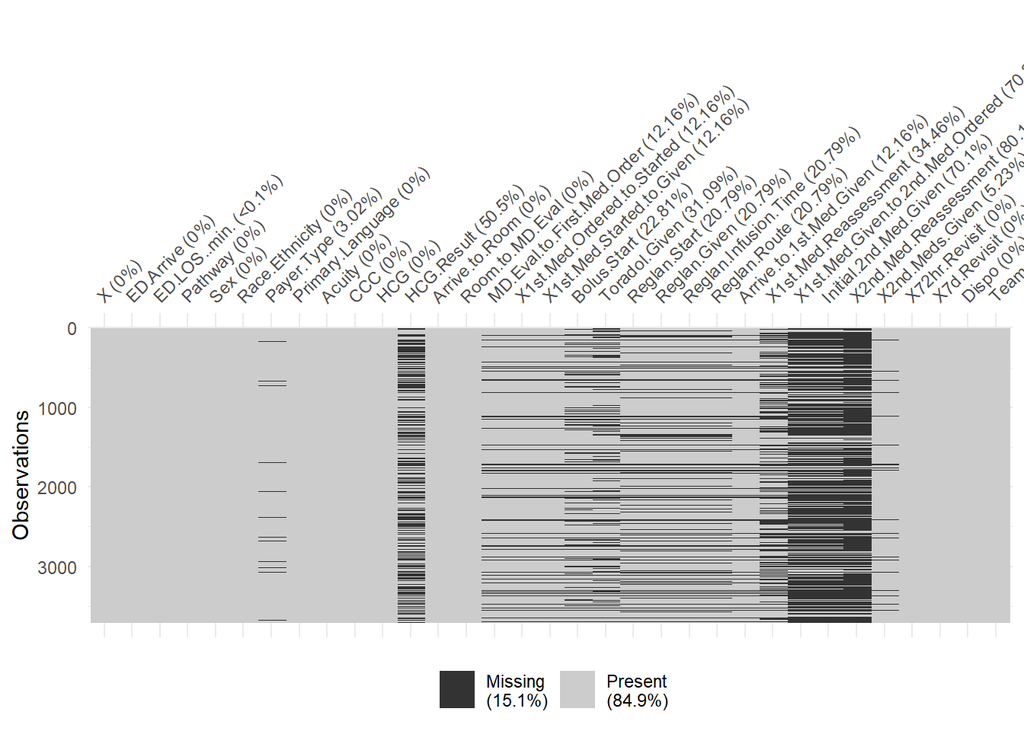

```r
vis_miss(data_all_na) #Highest concentration of missing NA's are in second med metrics and HCG, because not everyone gets a second med or HCG test.
```

```r
data_all_na %>%
  group_by(Race.Ethnicity) %>%
  miss_var_summary()
```

```
## # A tibble: 128 x 4
##    Race.Ethnicity variable                          n_miss pct_miss
##    <fct>          <chr>                              <int>    <dbl>
##  1 OTHER          X2nd.Med.Reassessment                144     79.6
##  2 OTHER          X1st.Med.Given.to.2nd.Med.Ordered    128     70.7
##  3 OTHER          Initial.2nd.Med.Given                127     70.2
##  4 OTHER          HCG.Result                           102     56.4
##  5 OTHER          X1st.Med.Reassessment                 69     38.1
##  6 OTHER          Toradol.Given                         66     36.5
##  7 OTHER          Bolus.Start                           52     28.7
##  8 OTHER          Reglan.Start                          42     23.2
##  9 OTHER          Reglan.Given                          42     23.2
## 10 OTHER          Reglan.Infusion.Time                  42     23.2
## # ... with 118 more rows
```

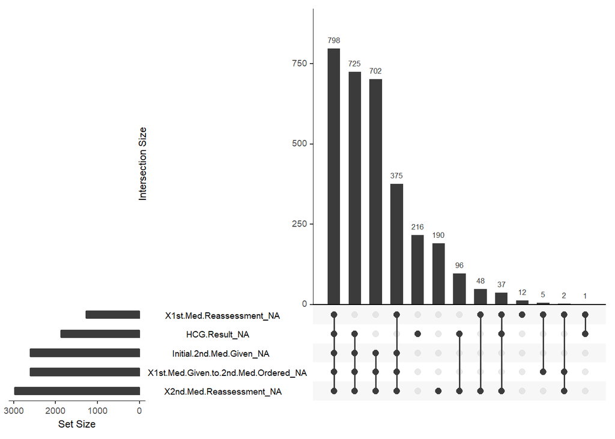

```r
gg_miss_upset(data_all_na) #Different visualization models of same data here,
```

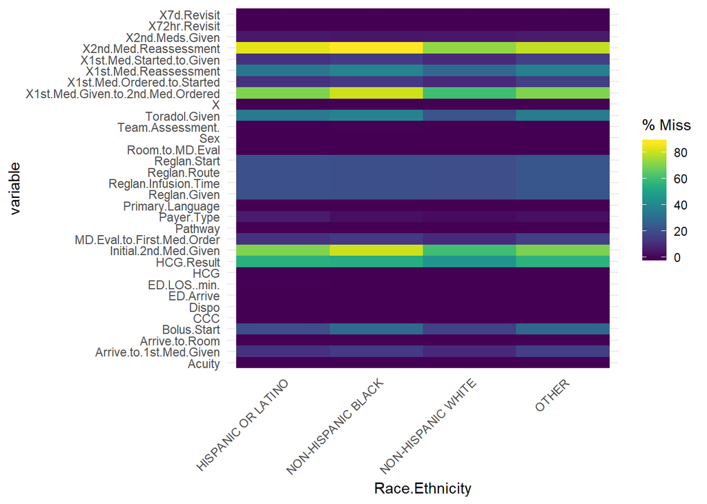

```r
gg_miss_fct(x = data_all_na, fct = Race.Ethnicity) #here, (differential gradiant possible amongst demographic groups)
```

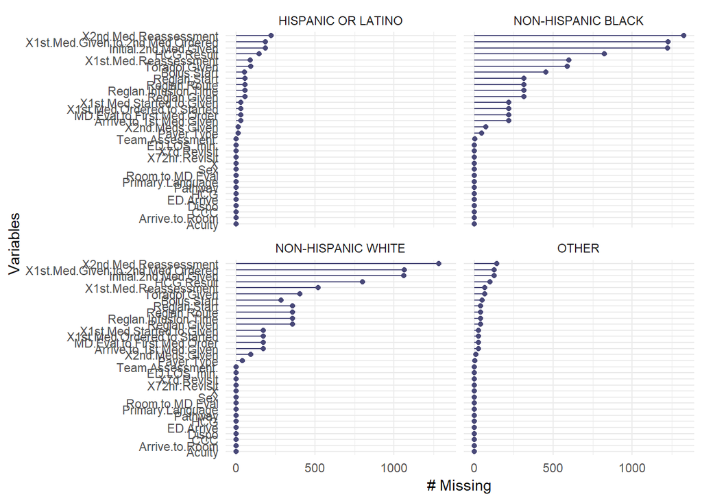

```r
gg_miss_var(data_all_na,facet = Race.Ethnicity) # and here.
```

Of the select variables I am interested in, the total percentage of missing data is 1.70%. The variable with the greatest precentage of missing data is “Arrival to first medication given” (12.16%), followed by “Payer Type” (3%), then Team Assessment (0.1%). When grouped by demographic status, the greatest percent of missing arrival to first med given is in the “Other” group(16.02%), followed by NH Black (14.40%), Hispanic (12.12%), then NH white (9.83%). Data visualization supports this, with a gradiant of missing values.

```r
pct_miss_select <- pct_miss(data_select)
print(pct_miss_select)
```

```
## [1] 1.698571
```

```r
miss_var_summ_select <- miss_var_summary(data_select) #Pcts of missing data in select variables
print(miss_var_summ_select)
```

```
## # A tibble: 9 x 3
##   variable                n_miss pct_miss
##   <chr>                    <int>    <dbl>
## 1 Arrive.to.1st.Med.Given    451   12.2
## 2 Payer.Type                 112    3.02
## 3 Team.Assessment.             4    0.108
## 4 Pathway                      0    0
## 5 Sex                          0    0
## 6 Race.Ethnicity               0    0
## 7 Primary.Language             0    0
## 8 Acuity                       0    0
## 9 Dispo                        0    0
```

```r
data_select %>%
  group_by(Race.Ethnicity) %>%
  miss_var_summary() #summarizing missing data in select variables across demographic groups
```

```
## # A tibble: 32 x 4
##    Race.Ethnicity     variable                n_miss pct_miss
##    <fct>              <chr>                    <int>    <dbl>
##  1 OTHER              Arrive.to.1st.Med.Given     29    16.0
##  2 OTHER              Payer.Type                   6     3.31
##  3 OTHER              Pathway                      0     0
##  4 OTHER              Sex                          0     0
##  5 OTHER              Primary.Language             0     0
##  6 OTHER              Acuity                       0     0
##  7 OTHER              Dispo                        0     0
##  8 OTHER              Team.Assessment.             0     0
##  9 HISPANIC OR LATINO Arrive.to.1st.Med.Given     32    12.1
## 10 HISPANIC OR LATINO Payer.Type                  16     6.06
## # ... with 22 more rows
```

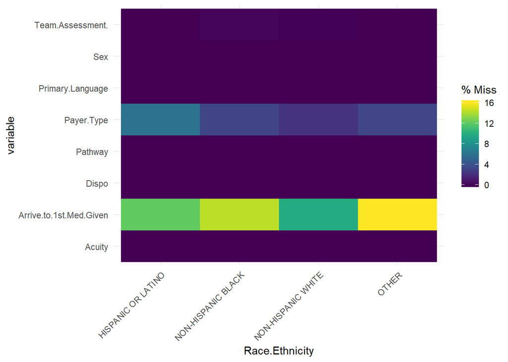

```r
gg_miss_fct(x = data_select, fct = Race.Ethnicity) #visualizing pct of missing data in select variables across demographic groups
```

### Data Quality evaluation: Internal validity

HCG Results: Although not all females will receive a HCG result (ie have not reached puberty), categorical and date time results should be equal. As it is, 2,045 observations had an HCG done but only 1836 have HCG date time stamps of resulted lab test. So ~10% are missing date time results. This would have to be further explored to see if this is due data transfer corruption, human factor error of manual data entry, or flowsheet misdocumentation error. If the data set included DOB, I could also compare expected number of HCG results vs actual.

```r
hcg_cat <- summary(data_all_na$HCG)
print(hcg_cat) #Categorical HCG resuts: No 1556, Yes 2045
```

```
##   No  Yes
## 1664 2045
```

```r
hcg_dt <- summary(data_all_na$HCG.Result) # HCG results with date time stamps
sum(is.na(data_all_na$HCG.Result)) # 1873 NA's in HCG results
```

```
## [1] 1873
```

```r
sum(!is.na(data_all_na$HCG.Result)) # 1836 have HCG results
```

```
## [1] 1836
```

```r
tot_sex <- summary(data_all_na$Sex)
print(tot_sex) # 2615 females , 1094 males
```

```
##    F    M
## 2615 1094
```

I also looked at the relationship between in missing data between arrival to first line med given and acuity level. Critical acuity level does not have as much missing Arrival to First med data, suggesting that those patients are the ones who all get a first line medication.

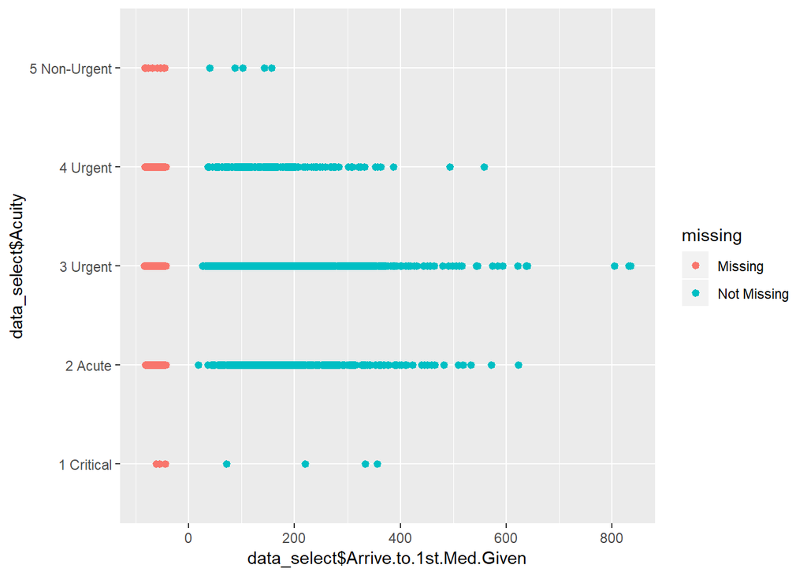

```r
ggplot(data_select,
       aes(x = data_select$Arrive.to.1st.Med.Given,
           y = data_select$Acuity)) +
 geom_miss_point() # visualizing missing data relationship between arrival to first line med given and acuity level
```

### Descriptive Statistics

Table 1. Categorical variables

In patients between the ages of 5-18, who are ordered the migraine pain order set: most are female and English speaking. Amongst the demographic groups, NHB and NHW are almost equal, with minority being Hispanic or other. Slightly more patients have private insurance compared to medical assistance. 3% of insurance data is not captured. Otherwise all the other fields have no missing data for these variables in this data set.

Only NA ‘s are in payer type. Of note, all these fields are non-mandatory in the EHR, but hardly any data is missing (only the payer type). Will come back to this in the conclusions, in discussing designing work flows . Not everything needs a hard stop to get 100% data entry.

```r
library(tableone) #Use tableone package to output table one counts and pcts of select data
tab_one <- CreateTableOne(data = data_select[c(2:5)], includeNA = TRUE)
print(tab_one, showAllLevels = TRUE)
```

```
##
##                        level              Overall
##   n                                       3709
##   Sex (%)              F                  2615 (70.5)
##                        M                  1094 (29.5)
##   Race.Ethnicity (%)   HISPANIC OR LATINO  264 ( 7.1)
##                        NON-HISPANIC BLACK 1514 (40.8)
##                        NON-HISPANIC WHITE 1750 (47.2)
##                        OTHER               181 ( 4.9)
##   Payer.Type (%)       COMMERCIAL         2089 (56.3)
##                        MEDICAL ASSISTANCE 1508 (40.7)
##                        <NA>                112 ( 3.0)
##   Primary.Language (%) ENGLISH            3641 (98.2)
##                        NON-ENGLISH          68 ( 1.8)
```

```r
tab_two <-CreateTableOne(data = data_select[c(-2,-3,-4,-5)])
print(tab_two, showAllLevels = TRUE)
```

```
##
##                                       level        Overall
##   n                                                  3709
##   Pathway (%)                         No              645 (17.4)
##                                       Yes            3064 (82.6)
##   Acuity (%)                          1 Critical        7 ( 0.2)
##                                       2 Acute         623 (16.8)
##                                       3 Urgent       2753 (74.2)
##                                       4 Urgent        312 ( 8.4)
##                                       5 Non-Urgent     14 ( 0.4)
##   Arrive.to.1st.Med.Given (mean (sd))              163.22 (85.47)
##   Dispo (%)                           Admitted        597 (16.1)
##                                       Discharged     3112 (83.9)
##   Team.Assessment. (%)                No             3414 (92.1)
##                                       Yes             291 ( 7.9)
```

```r
time_vars <- data_all_na %>%
  select(Race.Ethnicity, Arrive.to.1st.Med.Given, ED.LOS..min.,Arrive.to.Room, Room.to.MD.Eval, MD.Eval.to.First.Med.Order, X1st.Med.Ordered.to.Started, X1st.Med.Started.to.Given, X1st.Med.Reassessment) #select time variables related to first medication

time_vars_arr <- time_vars[c(1)] #race and ethnicity stats for arrival to first med only variable

describeBy(time_vars, time_vars$Race.Ethnicity) #summary of functions by demographic groups -> Group 1: Hisp, 2: NH Black, 3: NH White, 4: Other
```

```
##
##  Descriptive statistics by group
## group: HISPANIC OR LATINO
##                              vars   n   mean     sd median trimmed    mad
## Race.Ethnicity*                 1 264   1.00   0.00      1    1.00   0.00
## Arrive.to.1st.Med.Given         2 232 177.42  93.04    155  164.38  65.23
## ED.LOS..min.*                   3 263 253.08 143.07    225  238.79 134.92
## Arrive.to.Room                  4 264  25.06  34.85     10   17.32  11.12
## Room.to.MD.Eval                 5 264  22.30  30.71      9   16.01  11.86
## MD.Eval.to.First.Med.Order      6 232  55.79  52.53     43   47.18  29.65
## X1st.Med.Ordered.to.Started*    7 232  96.87  27.78     95   96.65  21.50
## X1st.Med.Started.to.Given*      8 232 121.64  81.05    140  122.08  92.66
## X1st.Med.Reassessment           9 173  71.27  50.83     56   62.98  35.58
##                              min max range  skew kurtosis   se
## Race.Ethnicity*                1   1     0   NaN      NaN 0.00
## Arrive.to.1st.Med.Given       39 831   792  2.38    10.73 6.11
## ED.LOS..min.*                 15 631   616  0.78    -0.08 8.82
## Arrive.to.Room                 0 193   193  2.45     6.55 2.14
## Room.to.MD.Eval               -3 196   199  2.61     8.99 1.89
## MD.Eval.to.First.Med.Order   -80 332   412  2.19     6.99 3.45
## X1st.Med.Ordered.to.Started*   4 157   153 -0.08     0.54 1.82
## X1st.Med.Started.to.Given*     1 258   257 -0.23    -1.28 5.32
## X1st.Med.Reassessment         20 317   297  2.19     6.36 3.86
## --------------------------------------------------------
## group: NON-HISPANIC BLACK
##                              vars    n   mean     sd median trimmed    mad
## Race.Ethnicity*                 1 1514   2.00   0.00      2    2.00   0.00
## Arrive.to.1st.Med.Given         2 1296 159.88  81.76    143  149.96  66.72
## ED.LOS..min.*                   3 1514 218.89 138.87    185  202.97 117.87
## Arrive.to.Room                  4 1514  25.64  38.61     10   16.79  11.86
## Room.to.MD.Eval                 5 1514  20.36  28.01     10   14.66  11.86
## MD.Eval.to.First.Med.Order      6 1296  48.80  46.77     37   41.24  26.69
## X1st.Med.Ordered.to.Started*    7 1296  92.32  25.63     91   91.63  19.27
## X1st.Med.Started.to.Given*      8 1296 113.95  84.44    123  112.42 115.64
## X1st.Med.Reassessment           9  915  65.77  44.10     55   59.05  28.17
##                               min max range  skew kurtosis   se
## Race.Ethnicity*                 2   2     0   NaN      NaN 0.00
## Arrive.to.1st.Med.Given        26 640   614  1.62     4.37 2.27
## ED.LOS..min.*                   2 637   635  1.01     0.57 3.57
## Arrive.to.Room                -51 405   456  3.18    14.49 0.99
```

[output cut: 34 more lines]

```
## Room.to.MD.Eval                 5 181  20.60  24.91   12.0   15.54  16.31
## MD.Eval.to.First.Med.Order      6 152  47.18  59.26   32.5   37.07  20.02
## X1st.Med.Ordered.to.Started*    7 152  91.67  25.72   91.0   92.10  17.79
## X1st.Med.Started.to.Given*      8 152 117.84  84.71  131.0  117.25 105.26
## X1st.Med.Reassessment           9 112  70.76  47.11   62.0   62.22  28.91
##                              min max range  skew kurtosis    se
## Race.Ethnicity*                4   4     0   NaN      NaN  0.00
## Arrive.to.1st.Med.Given       46 593   547  1.77     4.96  6.72
## ED.LOS..min.*                 28 615   587  0.75    -0.27 10.40
## Arrive.to.Room                 0 207   207  1.99     4.43  2.62
## Room.to.MD.Eval               -2 123   125  1.91     3.80  1.85
## MD.Eval.to.First.Med.Order   -69 498   567  4.20    24.82  4.81
## X1st.Med.Ordered.to.Started*   1 153   152 -0.34     1.17  2.09
## X1st.Med.Started.to.Given*     1 253   252 -0.15    -1.43  6.87
## X1st.Med.Reassessment         20 300   280  2.12     5.59  4.45
```

```r
describeBy(time_vars_arr, time_vars_arr$Race.Ethnicity)
```

```
##
##  Descriptive statistics by group
## group: HISPANIC OR LATINO
##    vars   n mean sd median trimmed mad min max range skew kurtosis se
## X1    1 264    1  0      1       1   0   1   1     0  NaN      NaN  0
## --------------------------------------------------------
## group: NON-HISPANIC BLACK
##    vars    n mean sd median trimmed mad min max range skew kurtosis se
## X1    1 1514    2  0      2       2   0   2   2     0  NaN      NaN  0
## --------------------------------------------------------
## group: NON-HISPANIC WHITE
##    vars    n mean sd median trimmed mad min max range skew kurtosis se
## X1    1 1750    3  0      3       3   0   3   3     0  NaN      NaN  0
## --------------------------------------------------------
## group: OTHER
##    vars   n mean sd median trimmed mad min max range skew kurtosis se
## X1    1 181    4  0      4       4   0   4   4     0  NaN      NaN  0
```

```r
#Create dataframes for each group
hisp <- subset(time_vars, time_vars$Race.Ethnicity == "HISPANIC OR LATINO")
nhw <- subset(time_vars, time_vars$Race.Ethnicity == "NON-HISPANIC WHITE")
nhb <- subset(time_vars, time_vars$Race.Ethnicity == "NON-HISPANIC BLACK")
other <- subset(time_vars, time_vars$Race.Ethnicity == "OTHER")

# Arrival to first medication descriptive statistics with histograms in separate demographic groups

all_hist <- ggplot(data_all_na, aes(Arrive.to.1st.Med.Given))+
  geom_histogram(binwidth = 10) +
  ggtitle("Time to first med given: All groups")+
  xlab("Arrival to first med given")+
  ylab("Frequency")
des_all <- describe.by(data_all_na)

hisp_hist <- ggplot(hisp, aes(Arrive.to.1st.Med.Given))+
  geom_histogram(binwidth = 10) +
  ggtitle("Time to first med given: Hispanic or Latino")+
  xlab("Arrival to first med given")+
  ylab("Frequency")
des_his <- describe.by(hisp)

nhw_hist <- ggplot(nhw, aes(Arrive.to.1st.Med.Given))+
  geom_histogram(binwidth = 10) +
  ggtitle("Time to first med given: Non-Hispanic White")+
  xlab("Arrival to first med given")+
  ylab("Frequency")

des_nhw <- describe.by(nhw)

nhb_hist <- ggplot(nhb, aes(Arrive.to.1st.Med.Given))+
  geom_histogram(binwidth = 10) +
  ggtitle("Time to first med given: Non-Hispanic Black")+
  xlab("Arrival to first med given")+
  ylab("Frequency")
des_nhb <- describe.by(nhb)

des_oth <- describe.by(other)
oth_hist <- ggplot(other, aes(Arrive.to.1st.Med.Given))+
  geom_histogram(binwidth = 10) +
  ggtitle("Time to first med given: Other")+
  xlab("Arrival to first med given")+
  ylab("Frequency")
```

```r
#Arrival to first med given in minutes, grouped by race/eth
arr_group_by_all <- data_all_na %>%
  group_by(Race.Ethnicity) %>%
  summarise(mean_arr = mean(Arrive.to.1st.Med.Given, na.rm = TRUE),
            sd_arr = sd(Arrive.to.1st.Med.Given, na.rm = TRUE),
            med_arr = median(Arrive.to.1st.Med.Given, na.rm = TRUE ),
            min_arr = min(Arrive.to.1st.Med.Given, na.rm = TRUE ),
            max_arr = max(Arrive.to.1st.Med.Given, na.rm = TRUE )) %>%
  arrange(desc(mean_arr), desc(med_arr), desc(min_arr), desc(max_arr)) %>%
  return
print.data.frame(arr_group_by_all)
```

```
##       Race.Ethnicity mean_arr   sd_arr med_arr min_arr max_arr
## 1 HISPANIC OR LATINO 177.4224 93.03745     155      39     831
## 2 NON-HISPANIC WHITE 164.1565 87.37185     143      18     835
## 3              OTHER 160.3882 82.81489     143      46     593
## 4 NON-HISPANIC BLACK 159.8750 81.76349     143      26     640
```

```r
#Arrival to first med given in minutes, grouped by lang
arr_group_by_all_lang <- data_all_na %>%
  group_by(Primary.Language) %>%
  summarise(mean_arr = mean(Arrive.to.1st.Med.Given, na.rm = TRUE),
            sd_arr = sd(Arrive.to.1st.Med.Given, na.rm = TRUE),
            med_arr = median(Arrive.to.1st.Med.Given, na.rm = TRUE ),
            min_arr = min(Arrive.to.1st.Med.Given, na.rm = TRUE ),
            max_arr = max(Arrive.to.1st.Med.Given, na.rm = TRUE )) %>%
  arrange(desc(mean_arr), desc(med_arr), desc(min_arr), desc(max_arr)) %>%
  return
```

Secondary outcomes Contingency (two-way) tables: Group table one variables by race and eth

```r
race_eth_all <- data_all_na$Race.Ethnicity
payer_type <- data_all_na$Payer.Type
sex_all <- data_all_na$Sex
pth_all <- data_all_na$Pathway
lng_all <- data_all_na$Primary.Language
acu_all <- data_all_na$Acuity
dis_all <- data_all_na$Dispo
team_all <- data_all_na$Team.Assessment.
arr_all <- data_all_na$Arrive.to.1st.Med.Given
```

```r
pth_by_tab <- table(race_eth_all,pth_all)
prop.table(pth_by_tab,2) %>%
  round (digits =2)
```

```
##                     pth_all
## race_eth_all           No  Yes
##   HISPANIC OR LATINO 0.07 0.07
##   NON-HISPANIC BLACK 0.48 0.39
##   NON-HISPANIC WHITE 0.40 0.49
##   OTHER              0.05 0.05
```

```r
prop.table(pth_by_tab,1)  %>%
  round (digits =2)
```

```
##                     pth_all
## race_eth_all           No  Yes
##   HISPANIC OR LATINO 0.17 0.83
##   NON-HISPANIC BLACK 0.21 0.79
##   NON-HISPANIC WHITE 0.15 0.85
##   OTHER              0.17 0.83
```

Acuity: 71% of children given acuity score 1 are NH white vs 14% are NH black 70% of NH black children given acuity score 3 vs 79% of NH white children.

```r
acu_by_tab <- addmargins(table(race_eth_all, acu_all))
print(acu_by_tab)
```

```
##                     acu_all
## race_eth_all         1 Critical 2 Acute 3 Urgent 4 Urgent 5 Non-Urgent
##   HISPANIC OR LATINO          0      58      180       24            2
##   NON-HISPANIC BLACK          1     207     1060      237            9
##   NON-HISPANIC WHITE          5     334     1376       35            0
##   OTHER                       1      24      137       16            3
##   Sum                         7     623     2753      312           14
##                     acu_all
## race_eth_all          Sum
##   HISPANIC OR LATINO  264
##   NON-HISPANIC BLACK 1514
##   NON-HISPANIC WHITE 1750
##   OTHER               181
##   Sum                3709
```

```r
acu_by_tab_p <-table(race_eth_all, acu_all)
prop.table(acu_by_tab_p,2) %>%
  round (digits =2)
```

```
##                     acu_all
## race_eth_all         1 Critical 2 Acute 3 Urgent 4 Urgent 5 Non-Urgent
##   HISPANIC OR LATINO       0.00    0.09     0.07     0.08         0.14
##   NON-HISPANIC BLACK       0.14    0.33     0.39     0.76         0.64
##   NON-HISPANIC WHITE       0.71    0.54     0.50     0.11         0.00
##   OTHER                    0.14    0.04     0.05     0.05         0.21
```

```r
prop.table(acu_by_tab_p,1)%>%
  round (digits =2)
```

```
##                     acu_all
## race_eth_all         1 Critical 2 Acute 3 Urgent 4 Urgent 5 Non-Urgent
##   HISPANIC OR LATINO       0.00    0.22     0.68     0.09         0.01
##   NON-HISPANIC BLACK       0.00    0.14     0.70     0.16         0.01
##   NON-HISPANIC WHITE       0.00    0.19     0.79     0.02         0.00
##   OTHER                    0.01    0.13     0.76     0.09         0.02
```

Disposition: 90% of black children are discharged vs 79% of white children and 85% of Hispanic children. White children are twice as likely to be admitted as black children.62% of admitted children are white vs 26% black vs 7% Hispanic. This makes sense if the acuity of white children is generally higher because of referral from osh but don’t have that data. This data leaves out transported patients.

```r
dis_by_tab <- addmargins(table(race_eth_all, dis_all))
print(dis_by_tab)
```

```
##                     dis_all
## race_eth_all         Admitted Discharged  Sum
##   HISPANIC OR LATINO       40        224  264
##   NON-HISPANIC BLACK      157       1357 1514
##   NON-HISPANIC WHITE      372       1378 1750
##   OTHER                    28        153  181
##   Sum                     597       3112 3709
```

```r
prop.table(dis_by_tab,2) %>%
  round (digits =2)
```

```
##                     dis_all
## race_eth_all         Admitted Discharged  Sum
##   HISPANIC OR LATINO     0.03       0.04 0.04
##   NON-HISPANIC BLACK     0.13       0.22 0.20
##   NON-HISPANIC WHITE     0.31       0.22 0.24
##   OTHER                  0.02       0.02 0.02
##   Sum                    0.50       0.50 0.50
```

```r
prop.table(dis_by_tab,1)%>%
  round (digits =2)
```

```
##                     dis_all
## race_eth_all         Admitted Discharged  Sum
##   HISPANIC OR LATINO     0.08       0.42 0.50
##   NON-HISPANIC BLACK     0.05       0.45 0.50
##   NON-HISPANIC WHITE     0.11       0.39 0.50
##   OTHER                  0.08       0.42 0.50
##   Sum                    0.08       0.42 0.50
```

Team assessment:

```r
team_by_tab <- table(race_eth_all, team_all)
print(team_by_tab)
```

```
##                     team_all
## race_eth_all           No  Yes
##   HISPANIC OR LATINO  239   25
##   NON-HISPANIC BLACK 1422   89
##   NON-HISPANIC WHITE 1586  163
##   OTHER               167   14
```

```r
prop.table(team_by_tab,2) %>%
  round (digits =2)
```

```
##                     team_all
## race_eth_all           No  Yes
##   HISPANIC OR LATINO 0.07 0.09
##   NON-HISPANIC BLACK 0.42 0.31
##   NON-HISPANIC WHITE 0.46 0.56
##   OTHER              0.05 0.05
```

```r
prop.table(team_by_tab,1)%>%
  round (digits =2)
```

```
##                     team_all
## race_eth_all           No  Yes
##   HISPANIC OR LATINO 0.91 0.09
##   NON-HISPANIC BLACK 0.94 0.06
##   NON-HISPANIC WHITE 0.91 0.09
##   OTHER              0.92 0.08
```

Another way to do contingency tables with chi sq:

```r
#Dispo by row
tab_x_dispo_r <- CrossTable(data_all_na$Race.Ethnicity, data_all_na$Dispo,
           digits = 2,
           prop.r = TRUE,
           prop.c = FALSE,
           prop.t = FALSE,
           prop.chisq = FALSE,
           chisq = TRUE,
           fisher = FALSE,
           mcnemar = FALSE
           )
```

```
##
##
##    Cell Contents
## |-------------------------|
## |                       N |
## |           N / Row Total |
## |-------------------------|
##
##
## Total Observations in Table:  3709
##
##
##                            | data_all_na$Dispo
## data_all_na$Race.Ethnicity |   Admitted | Discharged |  Row Total |
## ---------------------------|------------|------------|------------|
##         HISPANIC OR LATINO |         40 |        224 |        264 |
##                            |       0.15 |       0.85 |       0.07 |
## ---------------------------|------------|------------|------------|
##         NON-HISPANIC BLACK |        157 |       1357 |       1514 |
##                            |       0.10 |       0.90 |       0.41 |
## ---------------------------|------------|------------|------------|
##         NON-HISPANIC WHITE |        372 |       1378 |       1750 |
##                            |       0.21 |       0.79 |       0.47 |
## ---------------------------|------------|------------|------------|
##                      OTHER |         28 |        153 |        181 |
##                            |       0.15 |       0.85 |       0.05 |
## ---------------------------|------------|------------|------------|
##               Column Total |        597 |       3112 |       3709 |
## ---------------------------|------------|------------|------------|
##
##
## Statistics for All Table Factors
##
##
## Pearson's Chi-squared test
## ------------------------------------------------------------
## Chi^2 =  71.50122     d.f. =  3     p =  2.035897e-15
##
##
##
```

```r
#Dispo by col
tab_x_dispo_c <- CrossTable(data_all_na$Race.Ethnicity, data_all_na$Dispo,
           digits = 2,
           prop.r = FALSE,
           prop.c = TRUE,
           prop.t = FALSE,
           prop.chisq = FALSE,
           chisq = TRUE,
           fisher = FALSE,
           mcnemar = FALSE
           )
```

```
##
##
##    Cell Contents
## |-------------------------|
## |                       N |
## |           N / Col Total |
## |-------------------------|
##
##
## Total Observations in Table:  3709
##
##
##                            | data_all_na$Dispo
## data_all_na$Race.Ethnicity |   Admitted | Discharged |  Row Total |
## ---------------------------|------------|------------|------------|
##         HISPANIC OR LATINO |         40 |        224 |        264 |
##                            |       0.07 |       0.07 |            |
## ---------------------------|------------|------------|------------|
##         NON-HISPANIC BLACK |        157 |       1357 |       1514 |
##                            |       0.26 |       0.44 |            |
## ---------------------------|------------|------------|------------|
##         NON-HISPANIC WHITE |        372 |       1378 |       1750 |
##                            |       0.62 |       0.44 |            |
## ---------------------------|------------|------------|------------|
##                      OTHER |         28 |        153 |        181 |
##                            |       0.05 |       0.05 |            |
## ---------------------------|------------|------------|------------|
##               Column Total |        597 |       3112 |       3709 |
##                            |       0.16 |       0.84 |            |
## ---------------------------|------------|------------|------------|
##
##
## Statistics for All Table Factors
##
##
## Pearson's Chi-squared test
## ------------------------------------------------------------
## Chi^2 =  71.50122     d.f. =  3     p =  2.035897e-15
##
##
##
```

```r
#acuity, row and column outputs combined
tab_x_acu <- CrossTable(data_all_na$Race.Ethnicity, data_all_na$Acuity,
           digits = 2,
           prop.r = TRUE,
           prop.c = TRUE,
           prop.t = FALSE,
           prop.chisq = FALSE,
           chisq = TRUE,
           fisher = FALSE,
           mcnemar = FALSE
           )
```

```
##
##
##    Cell Contents
## |-------------------------|
## |                       N |
## |           N / Row Total |
## |           N / Col Total |
## |-------------------------|
##
##
## Total Observations in Table:  3709
##
##
##                            | data_all_na$Acuity
## data_all_na$Race.Ethnicity |   1 Critical |      2 Acute |     3 Urgent |     4 Urgent | 5 Non-Urgent |    Row Total |
## ---------------------------|--------------|--------------|--------------|--------------|--------------|--------------|
##         HISPANIC OR LATINO |            0 |           58 |          180 |           24 |            2 |          264 |
##                            |         0.00 |         0.22 |         0.68 |         0.09 |         0.01 |         0.07 |
##                            |         0.00 |         0.09 |         0.07 |         0.08 |         0.14 |              |
## ---------------------------|--------------|--------------|--------------|--------------|--------------|--------------|
##         NON-HISPANIC BLACK |            1 |          207 |         1060 |          237 |            9 |         1514 |
##                            |         0.00 |         0.14 |         0.70 |         0.16 |         0.01 |         0.41 |
##                            |         0.14 |         0.33 |         0.39 |         0.76 |         0.64 |              |
## ---------------------------|--------------|--------------|--------------|--------------|--------------|--------------|
##         NON-HISPANIC WHITE |            5 |          334 |         1376 |           35 |            0 |         1750 |
##                            |         0.00 |         0.19 |         0.79 |         0.02 |         0.00 |         0.47 |
##                            |         0.71 |         0.54 |         0.50 |         0.11 |         0.00 |              |
## ---------------------------|--------------|--------------|--------------|--------------|--------------|--------------|
##                      OTHER |            1 |           24 |          137 |           16 |            3 |          181 |
##                            |         0.01 |         0.13 |         0.76 |         0.09 |         0.02 |         0.05 |
##                            |         0.14 |         0.04 |         0.05 |         0.05 |         0.21 |              |
## ---------------------------|--------------|--------------|--------------|--------------|--------------|--------------|
##               Column Total |            7 |          623 |         2753 |          312 |           14 |         3709 |
##                            |         0.00 |         0.17 |         0.74 |         0.08 |         0.00 |              |
## ---------------------------|--------------|--------------|--------------|--------------|--------------|--------------|
##
##
## Statistics for All Table Factors
##
##
## Pearson's Chi-squared test
## ------------------------------------------------------------
## Chi^2 =  230.668     d.f. =  12     p =  1.447971e-42
##
##
##
```

```r
#Team assessment
tab_x_ta <- CrossTable(data_all_na$Race.Ethnicity, data_all_na$Team.Assessment.,
           digits = 2,
           prop.r = TRUE,
           prop.c = TRUE,
           prop.t = FALSE,
           prop.chisq = FALSE,
           chisq = TRUE,
           fisher = FALSE,
           mcnemar = FALSE
           )
```

```
##
##
##    Cell Contents
## |-------------------------|
## |                       N |
## |           N / Row Total |
## |           N / Col Total |
## |-------------------------|
##
##
## Total Observations in Table:  3705
##
##
##                            | data_all_na$Team.Assessment.
## data_all_na$Race.Ethnicity |        No |       Yes | Row Total |
## ---------------------------|-----------|-----------|-----------|
##         HISPANIC OR LATINO |       239 |        25 |       264 |
##                            |      0.91 |      0.09 |      0.07 |
##                            |      0.07 |      0.09 |           |
## ---------------------------|-----------|-----------|-----------|
##         NON-HISPANIC BLACK |      1422 |        89 |      1511 |
##                            |      0.94 |      0.06 |      0.41 |
##                            |      0.42 |      0.31 |           |
## ---------------------------|-----------|-----------|-----------|
##         NON-HISPANIC WHITE |      1586 |       163 |      1749 |
##                            |      0.91 |      0.09 |      0.47 |
##                            |      0.46 |      0.56 |           |
## ---------------------------|-----------|-----------|-----------|
##                      OTHER |       167 |        14 |       181 |
##                            |      0.92 |      0.08 |      0.05 |
##                            |      0.05 |      0.05 |           |
## ---------------------------|-----------|-----------|-----------|
##               Column Total |      3414 |       291 |      3705 |
##                            |      0.92 |      0.08 |           |
## ---------------------------|-----------|-----------|-----------|
##
##
## Statistics for All Table Factors
##
##
## Pearson's Chi-squared test
## ------------------------------------------------------------
## Chi^2 =  14.19878     d.f. =  3     p =  0.002646692
##
##
##
```

```r
#Pathway
tab_x_pth <- CrossTable(data_all_na$Race.Ethnicity, data_all_na$Pathway,
           digits = 2,
           prop.r = TRUE,
           prop.c = TRUE,
           prop.t = FALSE,
           prop.chisq = FALSE,
           chisq = TRUE,
           fisher = FALSE,
           mcnemar = FALSE
           )
```

```
##
##
##    Cell Contents
## |-------------------------|
## |                       N |
## |           N / Row Total |
## |           N / Col Total |
## |-------------------------|
##
##
## Total Observations in Table:  3709
##
##
##                            | data_all_na$Pathway
## data_all_na$Race.Ethnicity |        No |       Yes | Row Total |
## ---------------------------|-----------|-----------|-----------|
##         HISPANIC OR LATINO |        45 |       219 |       264 |
##                            |      0.17 |      0.83 |      0.07 |
##                            |      0.07 |      0.07 |           |
## ---------------------------|-----------|-----------|-----------|
##         NON-HISPANIC BLACK |       311 |      1203 |      1514 |
##                            |      0.21 |      0.79 |      0.41 |
##                            |      0.48 |      0.39 |           |
## ---------------------------|-----------|-----------|-----------|
##         NON-HISPANIC WHITE |       258 |      1492 |      1750 |
##                            |      0.15 |      0.85 |      0.47 |
##                            |      0.40 |      0.49 |           |
## ---------------------------|-----------|-----------|-----------|
##                      OTHER |        31 |       150 |       181 |
##                            |      0.17 |      0.83 |      0.05 |
##                            |      0.05 |      0.05 |           |
## ---------------------------|-----------|-----------|-----------|
##               Column Total |       645 |      3064 |      3709 |
##                            |      0.17 |      0.83 |           |
## ---------------------------|-----------|-----------|-----------|
##
##
## Statistics for All Table Factors
##
##
## Pearson's Chi-squared test
## ------------------------------------------------------------
## Chi^2 =  19.03442     d.f. =  3     p =  0.0002689549
##
##
##
```

#### Linear regression models

LM I For arrival to med time with race as the only preditor: Mean arrival-med time is longest for Hispanic population and that is significant. Black pts have 177 mins -17 mins mean time also significant. There is a trend towards shorter time to first med in other groups, but this is not significant.

```r
#Resetting levels of race/eth variable for trialing different intercept references in the lm functions to see if changed significance level or not
levels(data_all_na$Race.Ethnicity)[levels(data_all_na$Race.Ethnicity)=="HISPANIC OR LATINO"] <- "1"
levels(data_all_na$Race.Ethnicity)[levels(data_all_na$Race.Ethnicity)=="NON-HISPANIC BLACK"] <- "2"
levels(data_all_na$Race.Ethnicity)[levels(data_all_na$Race.Ethnicity)=="OTHER"] <- "3"
levels(data_all_na$Race.Ethnicity)[levels(data_all_na$Race.Ethnicity)=="NON-HISPANIC WHITE"] <- "4"

levels(data_all_na$Race.Ethnicity) # find the names of the levels
```

```
## [1] "1" "2" "4" "3"
```

```r
lm_race_arr <- lm(Arrive.to.1st.Med.Given ~ Race.Ethnicity, data=data_all_na)
summary(lm_race_arr)
```

```
##
## Call:
## lm(formula = Arrive.to.1st.Med.Given ~ Race.Ethnicity, data = data_all_na)
##
## Residuals:
##     Min      1Q  Median      3Q     Max
## -146.16  -58.33  -19.16   35.12  670.84
##
## Coefficients:
##                 Estimate Std. Error t value Pr(>|t|)
## (Intercept)      177.422      5.607  31.645  < 2e-16 ***
## Race.Ethnicity2  -17.547      6.088  -2.882  0.00397 **
## Race.Ethnicity4  -13.266      6.005  -2.209  0.02723 *
## Race.Ethnicity3  -17.034      8.911  -1.911  0.05603 .
## ---
## Signif. codes:  0 '***' 0.001 '**' 0.01 '*' 0.05 '.' 0.1 ' ' 1
##
## Residual standard error: 85.4 on 3254 degrees of freedom
##   (451 observations deleted due to missingness)
## Multiple R-squared:  0.002685,   Adjusted R-squared:  0.001766
## F-statistic: 2.921 on 3 and 3254 DF,  p-value: 0.03278
```

```r
an_race_arr <- anova(lm_race_arr)

coef(lm_race_arr) #Coefficients of X
```

```
##     (Intercept) Race.Ethnicity2 Race.Ethnicity4 Race.Ethnicity3
##       177.42241       -17.54741       -13.26589       -17.03426
```

```r
confint(lm_race_arr) #Confidence intervals
```

```
##                     2.5 %      97.5 %
## (Intercept)     166.42942 188.4154085
## Race.Ethnicity2 -29.48386  -5.6109634
## Race.Ethnicity4 -25.03928  -1.4924890
## Race.Ethnicity3 -34.50695   0.4384367
```

LM II Adding language as predictor variable does not eliminate the significance of the differences between Hispanic and nonhispanic black and nonhispanic white groups.

```r
lm_lang_race <- lm(Arrive.to.1st.Med.Given ~ Race.Ethnicity + Primary.Language, data=data_all_na)
summary(lm_lang_race)
```

```
##
## Call:
## lm(formula = Arrive.to.1st.Med.Given ~ Race.Ethnicity + Primary.Language,
##     data = data_all_na)
##
## Residuals:
##     Min      1Q  Median      3Q     Max
## -146.17  -58.17  -19.17   35.12  670.83
##
## Coefficients:
##                             Estimate Std. Error t value Pr(>|t|)
## (Intercept)                  177.733      5.807  30.605  < 2e-16 ***
## Race.Ethnicity2              -17.855      6.269  -2.848  0.00443 **
## Race.Ethnicity4              -13.567      6.182  -2.195  0.02825 *
## Race.Ethnicity3              -17.034      8.913  -1.911  0.05607 .
## Primary.LanguageNON-ENGLISH   -2.488     12.082  -0.206  0.83689
## ---
## Signif. codes:  0 '***' 0.001 '**' 0.01 '*' 0.05 '.' 0.1 ' ' 1
##
## Residual standard error: 85.41 on 3253 degrees of freedom
##   (451 observations deleted due to missingness)
## Multiple R-squared:  0.002698,   Adjusted R-squared:  0.001472
## F-statistic:   2.2 on 4 and 3253 DF,  p-value: 0.0665
```

LM III Including acuity as predictor vairable does not seem to change results for race - NonHispanic black and Non Hispanic white patients still have significantly less arrive-med time compared to Hispanic/Latino patients. Though it is interesting to note there is significantly less arrive-med time for less urgent cases.

```r
lm_lang_acu_race <- lm(Arrive.to.1st.Med.Given ~ Race.Ethnicity + Primary.Language + Acuity, data=data_all_na)
summary(lm_lang_acu_race)
```

```
##
## Call:
## lm(formula = Arrive.to.1st.Med.Given ~ Race.Ethnicity + Primary.Language +
##     Acuity, data = data_all_na)
##
## Residuals:
##     Min      1Q  Median      3Q     Max
## -174.75  -57.76  -19.02   36.09  674.25
##
## Coefficients:
##                             Estimate Std. Error t value Pr(>|t|)
## (Intercept)                  259.010     42.969   6.028 1.85e-09 ***
## Race.Ethnicity2              -16.254      6.271  -2.592  0.00959 **
## Race.Ethnicity4              -13.262      6.162  -2.152  0.03145 *
## Race.Ethnicity3              -14.995      8.899  -1.685  0.09206 .
## Primary.LanguageNON-ENGLISH   -3.233     12.090  -0.267  0.78915
## Acuity2 Acute                -66.411     42.707  -1.555  0.12004
## Acuity3 Urgent               -84.993     42.585  -1.996  0.04604 *
## Acuity4 Urgent               -89.907     43.026  -2.090  0.03673 *
## Acuity5 Non-Urgent          -137.660     57.178  -2.408  0.01611 *
## ---
## Signif. codes:  0 '***' 0.001 '**' 0.01 '*' 0.05 '.' 0.1 ' ' 1
##
## Residual standard error: 85.09 on 3249 degrees of freedom
##   (451 observations deleted due to missingness)
## Multiple R-squared:  0.01145,    Adjusted R-squared:  0.009018
## F-statistic: 4.705 on 8 and 3249 DF,  p-value: 9.488e-06
```

#### Conclusions

Extra care needed when interpreting data retrieved from time stamps in EHR queries. Differences in migraine pain management do exist. Missing data patterns can inform discovery process in clinical decision support to reduce variation in management.